# AFDMD-111 Estadística

Cálculo de probabilidad de VAs

# Variables aleatorias discretas

Como se ha mencionado en clases pasadas existen tres tipos de variables aleatorias; discretas, continuas y mixtas. Para nuestro curso, estaremos interesados en las variables aleatorias discretas y continuas. Recordemos que para las variables aleatorias discretas contamos con dos funciones que las describen totalmente; la función de distribución y la función de densidad. La función de distribución está dada por:
$$F_X(x) = P(X \le x)$$
para cualquier valor $x \in \mathbb{R}$. La función de masa de probabilidad es la otra función que se define de la siguiente manera:
$$p_X(k) = P(X=k)$$
Por lo tanto, cuando se nos dá una variable aleatoria discreta ésta está definida por una fórmula que representa $p_X(k)$ o $F_X(x)$. La variable aleatoria binomial, por ejemplo está dada por:
$$p_X(k) = \binom{n}{k}p^k(1-p)^{n-k}\; \;\;\; k=0,1,2, \ldots n$$
En R, los comandos `dbinom, pbinom, rbinom` y `qbinom` generan las pmfs, distribuciones y números aleatorios relacionados a la variable aleatoria discreta Binomial. Por ejemplo, el siguiente código genera $100$ números aleatorios de una distriubción binomial con parámetros $n=16$, $p=0.1$ y posteriormente se grafican.

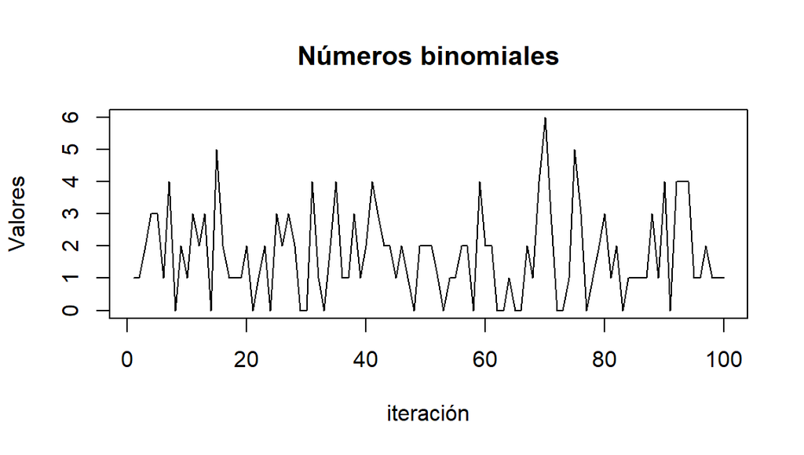

```r
vars <-rbinom(100, size=16, prob=0.1)
plot(vars, type="l", main="Números binomiales", xlab="iteración", ylab="Valores")
```

## Actividad

Investigue la generación de *pmfs* y *cdfs* discretas en R o python y posteriormente calcule las siguientes probabilidades usando únicamente código:

1. Sea $X$ una variable aleatoria que tiene distribución binomial con $p=0.4$ y $n=20$. Calcular:
1. $P(X\le 6)$

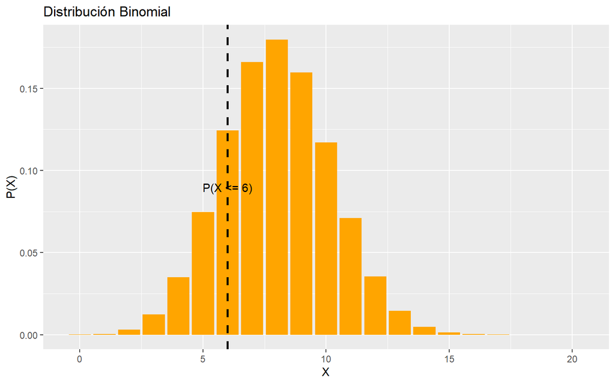

```r
library(ggplot2)

# Definir los parámetros
p <- 0.4  # Probabilidad de exito
n <- 20   # Numero

# Crear un dataframe con la distribución binomial
df <- data.frame(x = 0:n)
df$probabilidad <- dbinom(df$x, size = n, prob = p)

# Crear un gráfico de barras de la distribución binomial
ggplot(df, aes(x, probabilidad)) +
  geom_bar(stat = "identity", fill = "orange") +
  geom_vline(aes(xintercept = 6), linetype = "dashed", color = "black", size = 1) +
  annotate("text", x = 6, y = max(df$probabilidad)/2, label = "P(X <= 6)", color = "black") +
  labs(x = "X", y = "P(X)", title = "Distribución Binomial")
```

2. $P(X\ge 12)$

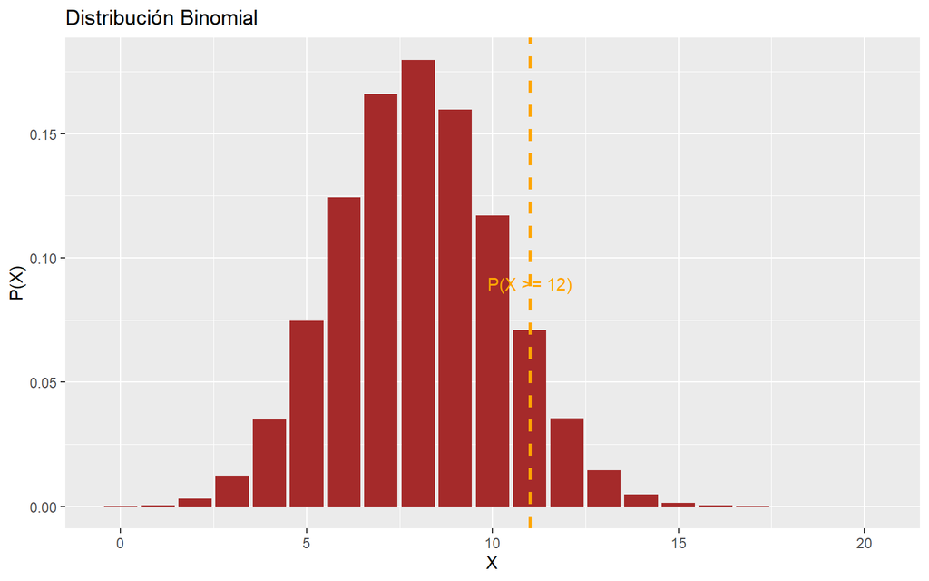

```r
p <- 0.4  # Probabilidad de éxito
n <- 20   # Número de ensayos

# Calcular P(X >= 12)
probabilidad <- 1 - pbinom(11, size = n, prob = p)

df <- data.frame(x = 0:n)
df$probabilidad <- dbinom(df$x, size = n, prob = p)

# Crear un gráfico de barras de la distribución binomial
ggplot(df, aes(x, probabilidad)) +
  geom_bar(stat = "identity", fill = "brown") +
  geom_vline(aes(xintercept = 11), linetype = "dashed", color = "orange", size = 1) +
  annotate("text", x = 11, y = max(df$probabilidad)/2, label = "P(X >= 12)", color = "orange") +
  labs(x = "X", y = "P(X)", title = "Distribución Binomial")
```

3. $P(X=8)$

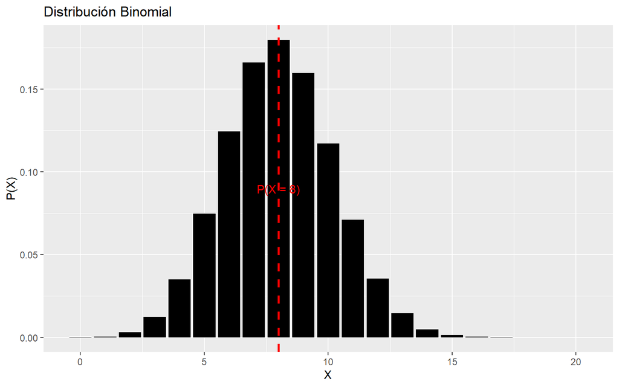

```r
p <- 0.4  # Probabilidad de éxito
n <- 20   # Número de ensayos

# Calcular P(X = 8)
probabilidad <- dbinom(8, size = n, prob = p)

df <- data.frame(x = 0:n)
df$probabilidad <- dbinom(df$x, size = n, prob = p)

# Crear un gráfico de barras de la distribución binomial
ggplot(df, aes(x, probabilidad)) +
  geom_bar(stat = "identity", fill = "black") +
  geom_vline(aes(xintercept = 8), linetype = "dashed", color = "red", size = 1) +
  annotate("text", x = 8, y = max(df$probabilidad)/2, label = "P(X = 8)", color = "red") +
  labs(x = "X", y = "P(X)", title = "Distribución Binomial")
```

2. El comando `sample`, me permite generar números aleatorios con una *pmf* que define el usuario. Generar 100 números aleatorios con las siguientes pmfs:
1. $p_X(k) = {5\choose k}\left(\frac{1}{5}\right)^k \left(\frac{4}{5}\right)^{5-k}, \;\; k=0,1,2,3,4,5.$

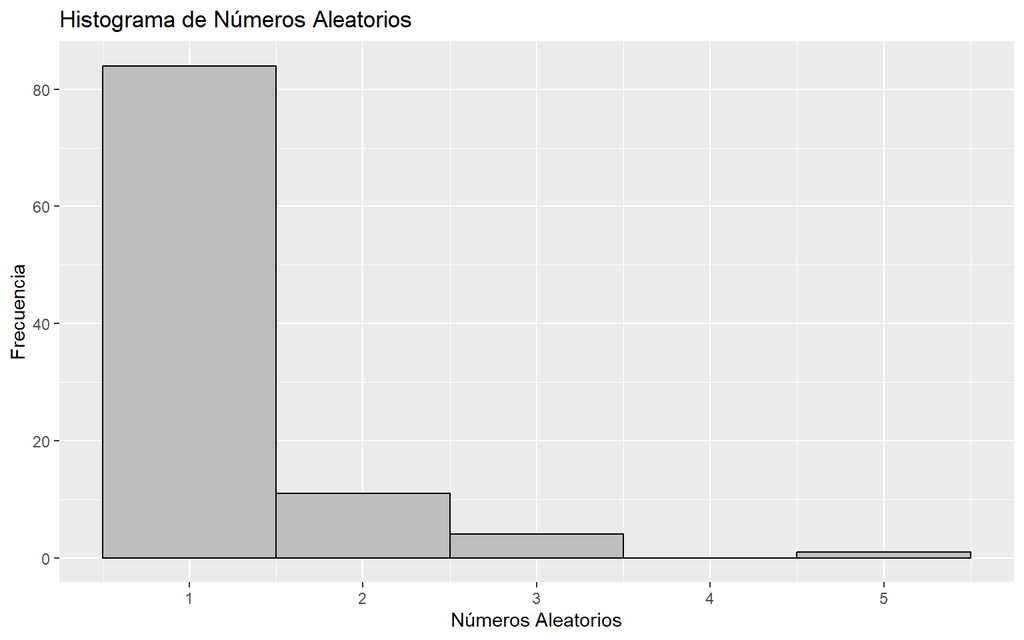

```r
k <- 1:5
probabilidades <- (5/k)*(1/5)^k*(4/5)^(5-k)

# Normalizar las probabilidades para que sumen 1
probabilidades <- probabilidades / sum(probabilidades)

# Generar 100 números aleatorios con la pmf dada
numeros_aleatorios <- sample(k, size = 100, replace = TRUE, prob = probabilidades)

f <- data.frame(numeros_aleatorios)

# Crear un histograma de los números aleatorios
ggplot(f, aes(numeros_aleatorios)) +
  geom_histogram(binwidth = 1, fill = "gray", color = "black") +
  labs(x = "Números Aleatorios", y = "Frecuencia", title = "Histograma de Números Aleatorios")
```

2. $p_X(k) = \frac{k^2}{2870}, \;\; k=0,1,2,3,\ldots, 19, 20$

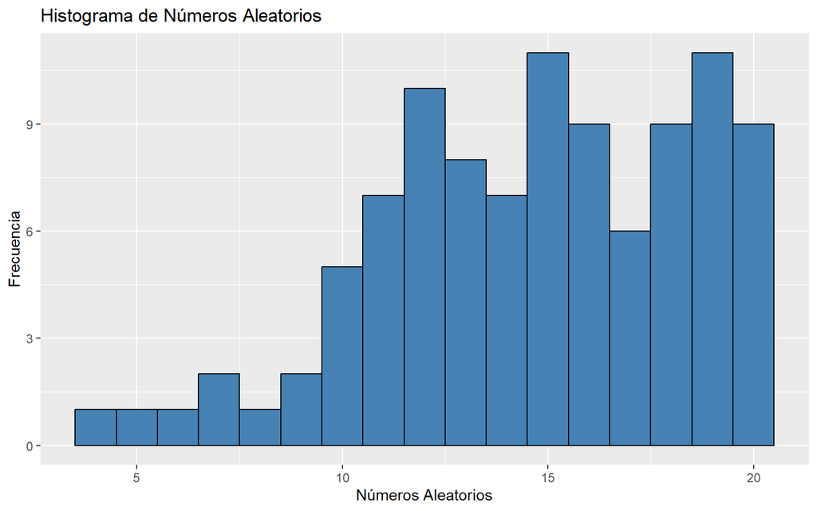

```r
k <- 0:20
probabilidades <- (k^2) / 2870

# Normalizar las probabilidades para que sumen 1
probabilidades <- probabilidades / sum(probabilidades)

# Generar 100 números aleatorios con la pmf dada
numeros_aleatorios <- sample(k, size = 100, replace = TRUE, prob = probabilidades)

df <- data.frame(numeros_aleatorios)

# Crear un histograma de los números aleatorios
ggplot(df, aes(numeros_aleatorios)) +
  geom_histogram(binwidth = 1, fill = "steelblue", color = "black") +
  labs(x = "Números Aleatorios", y = "Frecuencia", title = "Histograma de Números Aleatorios")
```

c. $p_X(k) = \log_{10}\left(\frac{k+1}{k}\right)\; \; k=1,2,3, \ldots 9$

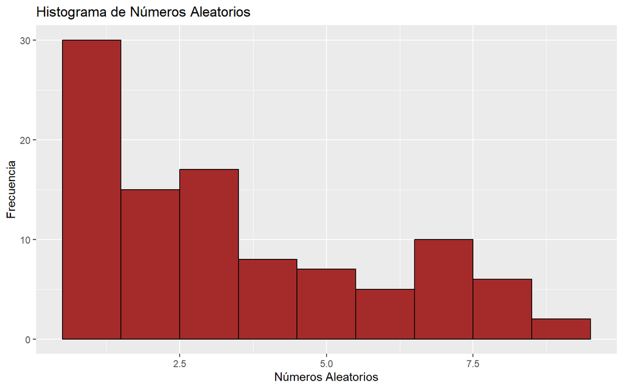

```r
k <- 1:9
probabilidades <- log10((k+1) / k)

# Normalizar las probabilidades para que sumen 1
probabilidades <- probabilidades / sum(probabilidades)

# Generar 100 números aleatorios con la pmf dada
numeros_aleatorios <- sample(k, size = 100, replace = TRUE, prob = probabilidades)

df <- data.frame(numeros_aleatorios)

# Crear un histograma de los números aleatorios
ggplot(df, aes(numeros_aleatorios)) +
  geom_histogram(binwidth = 1, fill = "brown", color = "black") +
  labs(x = "Números Aleatorios", y = "Frecuencia", title = "Histograma de Números Aleatorios")
```

3. La variable aleatoria binomial depende de los parámetros $n$ y $p$. Grafique las pmfs y cdfs para (Nota para graficar por parejas puede usar el comando `par(mfrow=(filas, columnas))`) y responda las preguntas:
1. $n=10$ y $p=1/2$

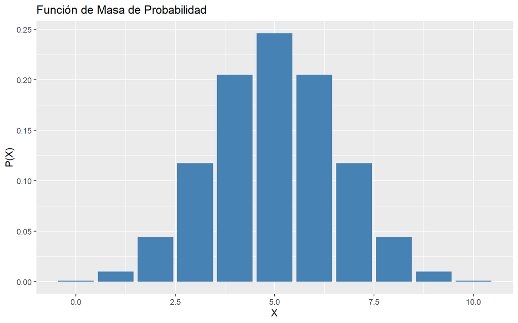

```r
n <- 10   # Número de ensayos
p <- 0.5  # Probabilidad de éxito

# Crear un dataframe con la distribución binomial
df <- data.frame(x = 0:n)
df$pmf <- dbinom(df$x, size = n, prob = p)
df$cdf <- pbinom(df$x, size = n, prob = p)

par(mfrow = c(1, 2))

# Graficar la pmf
ggplot(df, aes(x, pmf)) +
  geom_bar(stat = "identity", fill = "steelblue") +
  labs(x = "X", y = "P(X)", title = "Función de Masa de Probabilidad")
```

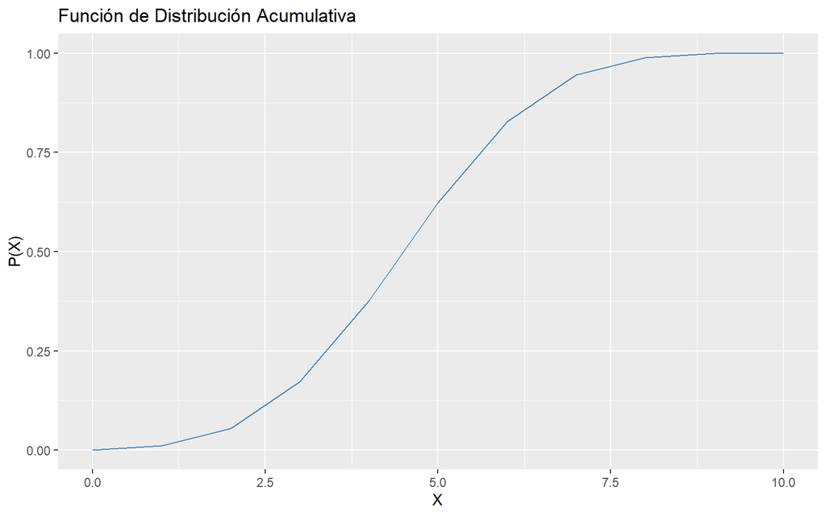

```r
# Graficar la cdf
ggplot(df, aes(x, cdf)) +
  geom_line(color = "steelblue") +
  labs(x = "X", y = "P(X)", title = "Función de Distribución Acumulativa")
```

2. $n=10$ y $p=1/8$

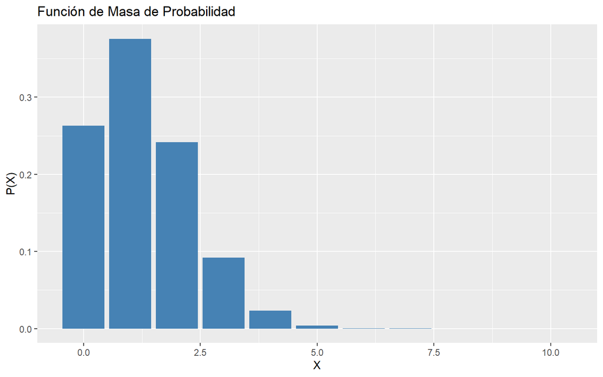

```r
n <- 10   # Número de ensayos
p <- 1/8  # Probabilidad de éxito

# Crear un dataframe con la distribución binomial
df <- data.frame(x = 0:n)
df$pmf <- dbinom(df$x, size = n, prob = p)
df$cdf <- pbinom(df$x, size = n, prob = p)

# Graficar la pmf y la cdf en un solo gráfico
par(mfrow = c(1, 2))

# Graficar la pmf
ggplot(df, aes(x, pmf)) +
  geom_bar(stat = "identity", fill = "steelblue") +
  labs(x = "X", y = "P(X)", title = "Función de Masa de Probabilidad")
```

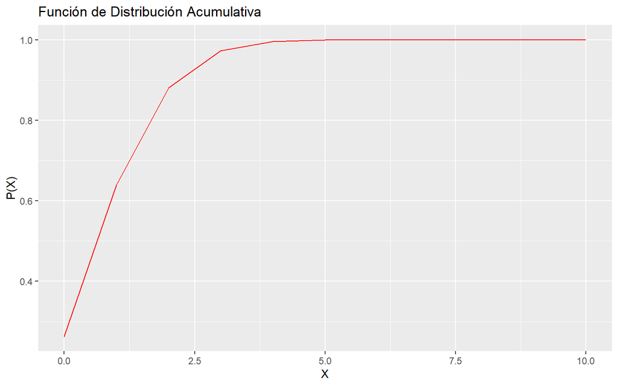

```r
# Graficar la cdf
ggplot(df, aes(x, cdf)) +
  geom_line(color = "red") +
  labs(x = "X", y = "P(X)", title = "Función de Distribución Acumulativa")
```

3. $n=10$ y $4/5$

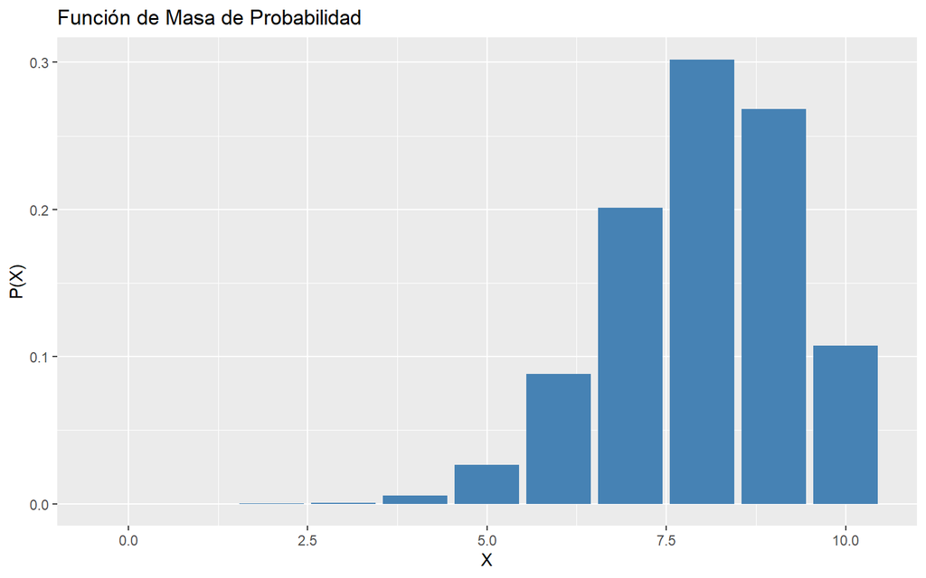

```r
n <- 10   # Número de ensayos
p <- 4/5  # Probabilidad de éxito

# Crear un dataframe con la distribución binomial
df <- data.frame(x = 0:n)
df$pmf <- dbinom(df$x, size = n, prob = p)
df$cdf <- pbinom(df$x, size = n, prob = p)

# Graficar la pmf y la cdf en un solo gráfico
par(mfrow = c(1, 2))

# Graficar la pmf
ggplot(df, aes(x, pmf)) +
  geom_bar(stat = "identity", fill = "steelblue") +
  labs(x = "X", y = "P(X)", title = "Función de Masa de Probabilidad")
```

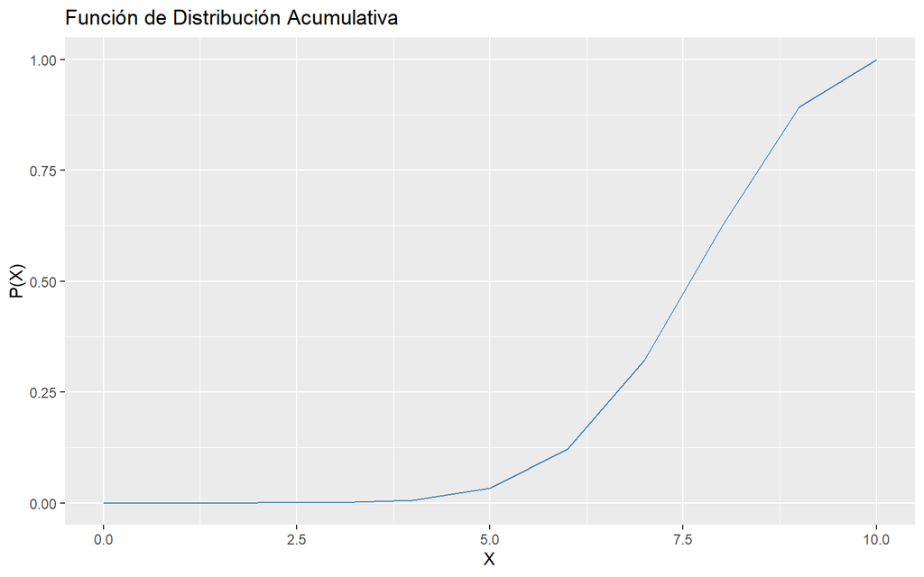

```r
# Graficar la cdf
ggplot(df, aes(x, cdf)) +
  geom_line(color = "steelblue") +
  labs(x = "X", y = "P(X)", title = "Función de Distribución Acumulativa")
```

4. $n=10$ y $p=1/2$

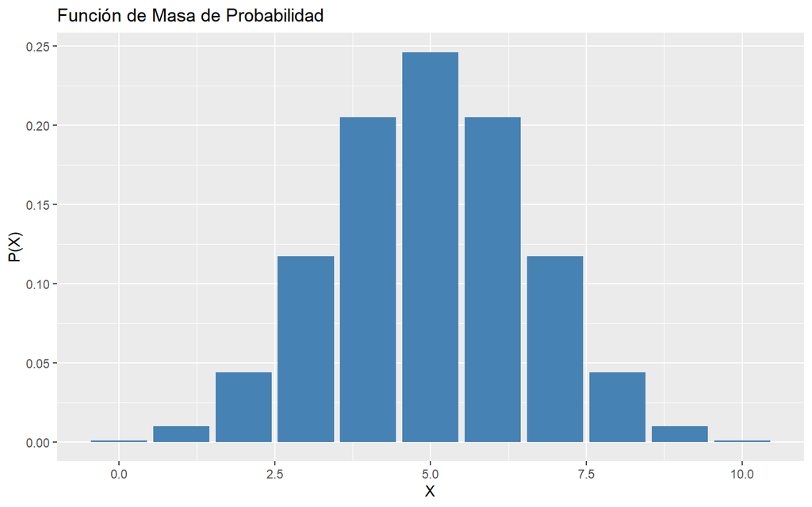

```r
n <- 10   # Número de ensayos
p <- 1/2  # Probabilidad de éxito

# Crear un dataframe con la distribución binomial
df <- data.frame(x = 0:n)
df$pmf <- dbinom(df$x, size = n, prob = p)
df$cdf <- pbinom(df$x, size = n, prob = p)

# Graficar la pmf y la cdf en un solo gráfico
par(mfrow = c(1, 2))

# Graficar la pmf
ggplot(df, aes(x, pmf)) +
  geom_bar(stat = "identity", fill = "steelblue") +
  labs(x = "X", y = "P(X)", title = "Función de Masa de Probabilidad")
```

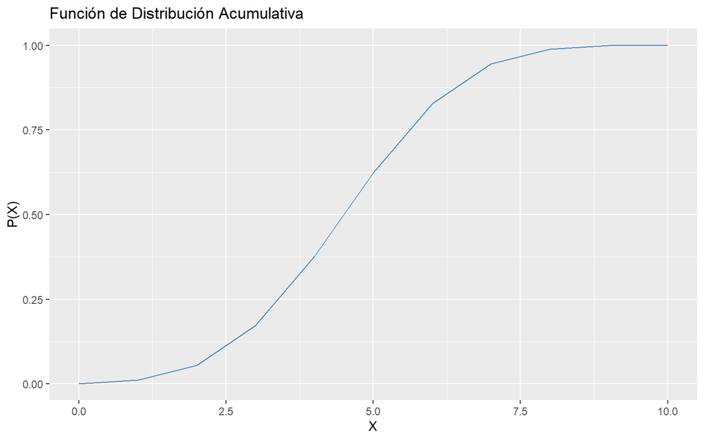

```r
# Graficar la cdf
ggplot(df, aes(x, cdf)) +
  geom_line(color = "steelblue") +
  labs(x = "X", y = "P(X)", title = "Función de Distribución Acumulativa")
```

El parámetro p en una distribución binomial tiene un efecto significativo en la asimetría de la distribución.

- Cuando p=0.5, la distribución es simétrica, lo que significa que los valores a ambos lados del valor medio tienen la misma probabilidad.
- Cuando p<0.5, la distribución está sesgada hacia la derecha, lo que significa que los valores menores tienen una mayor probabilidad.
- Cuando p>0.5, la distribución está sesgada hacia la izquierda, lo que significa que los valores mayores tienen una mayor probabilidad.

# Variables aletorias continuas

Las variables aleatorias continuas, a diferencia de las discretas, quedan totalmente definidas mediante su PDF y CDF. Existen múltiples variables aleatorias bien conocidas y que sirven para modelar diversos fenómenos. La densidad Gamma está dada por la siguiente ecuación:
$$f_X(x, \alpha, \beta) = \begin{cases}
\frac{\beta^{\alpha}}{\Gamma(\alpha)} x^{\alpha-1} \mbox{e}^{-\beta x}
& x>0\\
0 & x\le 0
\end{cases}$$
donde $\alpha>0$ y $\beta >0$.

## Actividad

1. ¿Qué efecto tiene incrementar $\alpha$? Grafique para contestar.

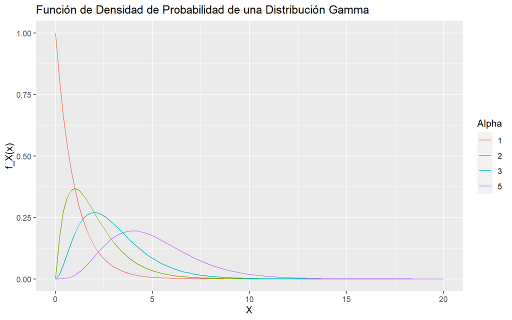

```r
x <- seq(0, 20, length.out = 100)

# Definir los valores de alpha y beta
alpha_values <- c(1, 2, 3, 5)
beta <- 1

# Crear un dataframe para cada valor de alpha
df_list <- lapply(alpha_values, function(alpha) {
  df <- data.frame(x = x)
  df$alpha <- alpha
  df$beta <- beta
  df$pdf <- dgamma(x, shape = alpha, rate = beta)
  return(df)
})

# Combinar todos los dataframes en uno solo
df <- do.call(rbind, df_list)

# Graficar la pdf para cada valor de alpha
ggplot(df, aes(x, pdf, color = factor(alpha))) +
  geom_line() +
  labs(x = "X", y = "f_X(x)", color = "Alpha",
       title = "Función de Densidad de Probabilidad de una Distribución Gamma")
```

Otra variable aleatoria de interés es la variable aleatoria de Cauchy que está definida de la siguiente manera:

$$f_X(x) = \frac{\beta}{\pi ([x-\alpha]^2 + \beta^2)}$$
donde $\alpha \in \mathbb{R}$ y $\beta >0$. Supógamos que $\alpha = 5$.

## Actividad

1. ¿Qué efecto tiene $\beta$ en la función de densidad? Grafique para contestar.

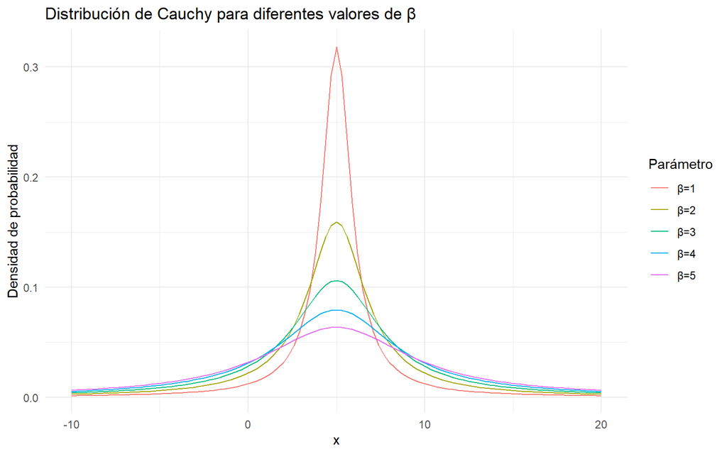

```r
df <- data.frame(x = seq(-10, 20, length.out = 1000))

alpha <- 5

ggplot(df, aes(x = x)) +
  stat_function(fun = dcauchy, args = list(location = alpha, scale = 1), aes(colour = "β=1")) +
  stat_function(fun = dcauchy, args = list(location = alpha, scale = 2), aes(colour = "β=2")) +
  stat_function(fun = dcauchy, args = list(location = alpha, scale = 3), aes(colour = "β=3")) +
  stat_function(fun = dcauchy, args = list(location = alpha, scale = 4), aes(colour = "β=4")) +
  stat_function(fun = dcauchy, args = list(location = alpha, scale = 5), aes(colour = "β=5")) +
  labs(title='Distribución de Cauchy para diferentes valores de β', x='x', y='Densidad de probabilidad', colour='Parámetro') +
  theme_minimal()
```

Supóngamos que tenemos la siguiente PDF:
$$f_X(x) = \begin{cases}
0 & x < a\\
\frac{2(x-a)}{(b-a)(c-a)} & a \le x < c\\
\frac{2}{b-a} & x=c\\
\frac{2(b-x)}{(b-a)(b-c)} & c < x \le b\\
0 & b < x
\end{cases}$$
donde $a < c < c$.

## Actividad

1. Grafique la densidad triangular cuando $a=0$, $b=4$, $c=2$

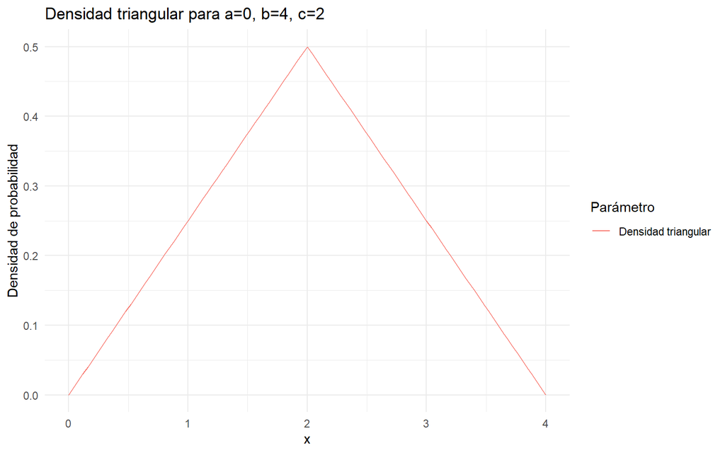

```r
df <- data.frame(x = seq(0, 4, length.out = 1000))

a <- 0
b <- 4
c <- 2

ggplot(df, aes(x = x)) +
  stat_function(fun = function(x) {
    ifelse(x < a, 0,
           ifelse(x < c, 2*(x-a)/((b-a)*(c-a)),
                  ifelse(x <= b, 2*(b-x)/((b-a)*(b-c)), 0)))
  }, aes(colour = "Densidad triangular")) +
  labs(title='Densidad triangular para a=0, b=4, c=2', x='x', y='Densidad de probabilidad', colour='Parámetro') +
  theme_minimal()
```

2. Grafique la densidad triangular cuando $a=1$, $c=2$, $b=4$

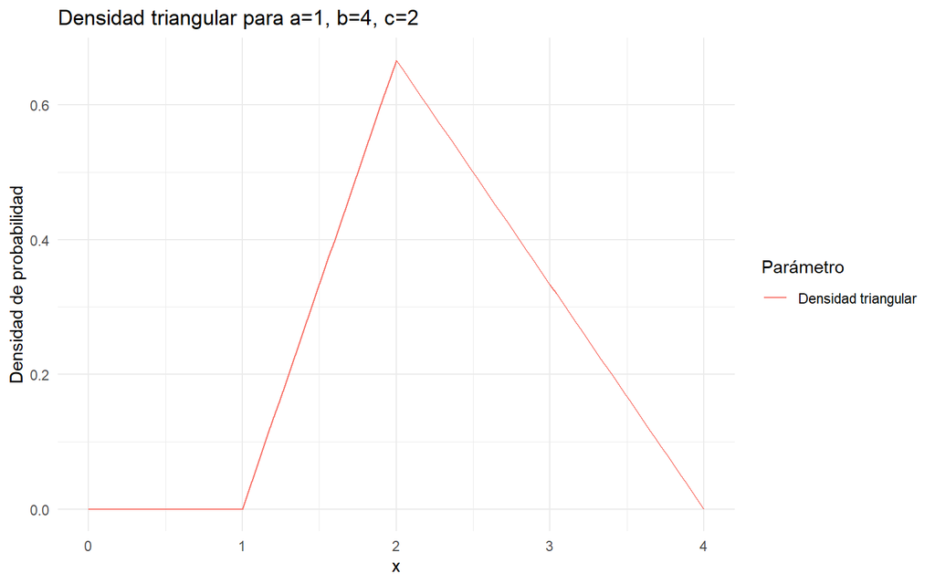

```r
df <- data.frame(x = seq(0, 4, length.out = 1000))

a <- 1
b <- 4
c <- 2

ggplot(df, aes(x = x)) +
  stat_function(fun = function(x) {
    ifelse(x < a, 0,
           ifelse(x < c, 2*(x-a)/((b-a)*(c-a)),
                  ifelse(x <= b, 2*(b-x)/((b-a)*(b-c)), 0)))
  }, aes(colour = "Densidad triangular")) +
  labs(title='Densidad triangular para a=1, b=4, c=2', x='x', y='Densidad de probabilidad', colour='Parámetro') +
  theme_minimal()
```

3. Grafique la densidad triangular cuando $a=-1$, $c=0$, $b=1$

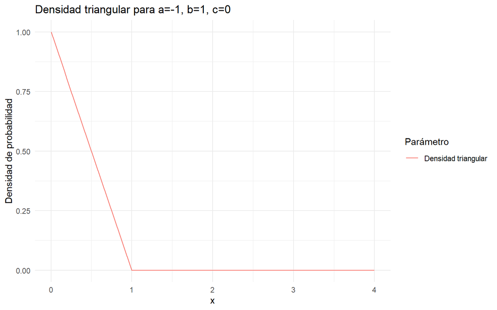

```r
df <- data.frame(x = seq(0, 4, length.out = 1000))

a <- -1
b <- 1
c <- 0

ggplot(df, aes(x = x)) +
  stat_function(fun = function(x) {
    ifelse(x < a, 0,
           ifelse(x < c, 2*(x-a)/((b-a)*(c-a)),
                  ifelse(x <= b, 2*(b-x)/((b-a)*(b-c)), 0)))
  }, aes(colour = "Densidad triangular")) +
  labs(title='Densidad triangular para a=-1, b=1, c=0', x='x', y='Densidad de probabilidad', colour='Parámetro') +
  theme_minimal()
```

Tanto `R` como `python` nos permiten calcular integrales usando los comandos básicos o bién usando sistemas de cómputo algebraíco. R, por ejemplo, puede utilizar un sistema llamado `Ryacas` que permite hacer muchos cálculos de forma simbólica. Ahora, consideremos que tenemos la siguiente PDF:

$$f_X(x) = \begin{cases}
\mbox{e}^{-x} & x \ge 0\\
0 & \mbox{resto}
\end{cases}$$

## Actividad

Calcular, usando los comando de integración o `Ryacas` o `python` las siguientes probabilidades usando la PDF de arriba:

1. $P(X>1)$

```r
library(Ryacas)
# Definir la función
f <- function(x) exp(-x)

# Calcular la integral
result <- integrate(f, lower = 1, upper = Inf)
print(result$value)
```

```
## [1] 0.3678794
```

2. $P(2 < X \le 4)$

```r
f <- function(x) exp(-x)

# Calcular la integral
result <- integrate(f, lower = 2, upper = 4)
print(result$value)
```

```
## [1] 0.1170196
```

3. $P(X \le 2)$

```r
f <- function(x) exp(-x)

# Calcular la integral
result <- integrate(f, lower = 0, upper = 2)
print(result$value)
```

```
## [1] 0.8646647
```

Finalmente, supongamos que tenemos la siguiente PDF:

$$f_X(x) = \frac{1}{\sqrt{2\pi}}\mbox{e}^{-\frac{(x-3)^2}{2}}$$

## Actividad

1. Graficar $f_X(3+x)$.

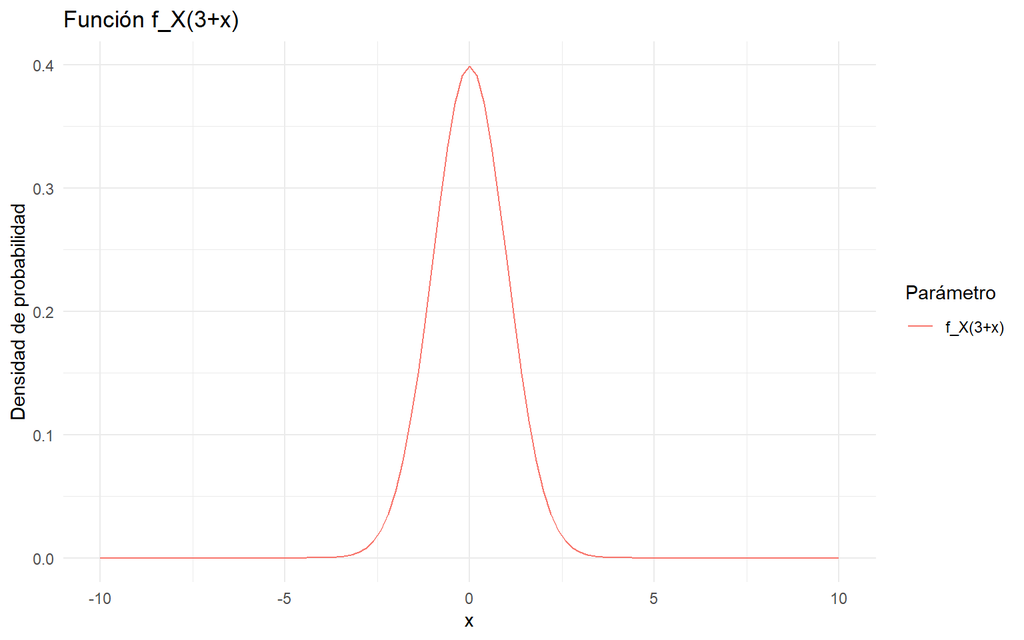

```r
f <- function(x) dnorm(3 + x, mean = 3, sd = 1)

# Crear un data frame con los valores de x
df <- data.frame(x = seq(-10, 10, length.out = 1000))

# Graficar la función
ggplot(df, aes(x = x)) +
  stat_function(fun = f, aes(colour = "f_X(3+x)")) +
  labs(title='Función f_X(3+x)', x='x', y='Densidad de probabilidad', colour='Parámetro') +
  theme_minimal()
```

2. Graficar $f_X(3-x)$.

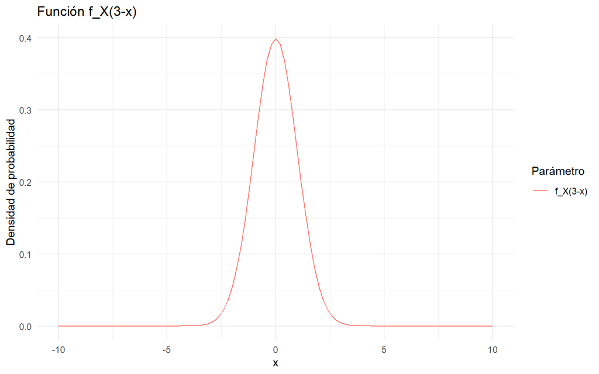

```r
f <- function(x) dnorm(3 - x, mean = 3, sd = 1)

# Crear un data frame con los valores de x
df <- data.frame(x = seq(-10, 10, length.out = 1000))

# Graficar la función
ggplot(df, aes(x = x)) +
  stat_function(fun = f, aes(colour = "f_X(3-x)")) +
  labs(title='Función f_X(3-x)', x='x', y='Densidad de probabilidad', colour='Parámetro') +
  theme_minimal()
```

3. Que hay en común entre estas dos gráficas y qué se puede inferir de $f_X(3+x)$ y $f_X(3-x)$

La función fX(3+x) representa un desplazamiento hacia la izquierda de la funcion original. Esto se debe a que al valor de x se le suma una constante, lo que resulta en un desplazamiento hacia la izquierda en el eje x.

## Fecha de entrega: miércoles 18 de octubre de 2023 a través de Moodle.